# Tarea 4: regresión logística

En esta tarea construiremos varios modelos de regresión logística y compararemos sus resultados.

### Preparación

Puedes usar el siguiente código, o tus implementaciones propias:

```r
source("tarea_4_codigo.R")
```

Revisa las funciones que están ahí. Son las que usamos en clase.

Usaremos los datos de sobrevivientes del hundimiento del Titanic, obtenidos de [este concurso de Kaggle](https://www.kaggle.com/c/titanic)

```r
library(tidyverse)
datos_titanic <- read_csv("./tarea_4_datos/train.csv")
```

En este caso, queremos predecir la variable *Survived* en términos del resto. Para simiplificar el ejericicio,

- solo usaremos alguna de las variables,
- ignoramos datos faltantes en la variable edad

```r
datos_titanic <- datos_titanic %>% select(Survived, Pclass, Age, Sex, Embarked) %>%
    filter(!is.na(Age), !is.na(Embarked))
summary(datos_titanic)
```

```
    Survived          Pclass          Age            Sex              Embarked
 Min.   :0.0000   Min.   :1.00   Min.   : 0.42   Length:712         Length:712
 1st Qu.:0.0000   1st Qu.:1.00   1st Qu.:20.00   Class :character   Class :character
 Median :0.0000   Median :2.00   Median :28.00   Mode  :character   Mode  :character
 Mean   :0.4045   Mean   :2.24   Mean   :29.64
 3rd Qu.:1.0000   3rd Qu.:3.00   3rd Qu.:38.00
 Max.   :1.0000   Max.   :3.00   Max.   :80.00
```

```r
head(datos_titanic)
```

| Survived | Pclass | Age | Sex | Embarked |
| --- | --- | --- | --- | --- |
| 0 | 3 | 22 | male | S |
| 1 | 1 | 38 | female | C |
| 1 | 3 | 26 | female | S |
| 1 | 1 | 35 | female | S |
| 0 | 3 | 35 | male | S |
| 0 | 1 | 54 | male | S |

La descripción de las variables es:

survival Survival 0 = No, 1 = Yes pclass Ticket class 1 = 1st, 2 = 2nd, 3 = 3rd sex Sex Age Age in years  
embarked Port of Embarkation C = Cherbourg, Q = Queenstown, S = Southampton

Convertimos las variables categóricas a numerícas creando indicadoras, como sigue:

```r
datos <- datos_titanic %>%
         mutate(female = as.numeric(Sex == "female"),
                southampton = as.numeric(Embarked == "S"),
                cherbourg = as.numeric(Embarked == "C")) %>%
        select(-Embarked, -Sex)
datos
```

| Survived | Pclass | Age | female | southampton | cherbourg |
| --- | --- | --- | --- | --- | --- |
| 0 | 3 | 22.00 | 0 | 1 | 0 |
| 1 | 1 | 38.00 | 1 | 0 | 1 |
| 1 | 3 | 26.00 | 1 | 1 | 0 |
| 1 | 1 | 35.00 | 1 | 1 | 0 |
| 0 | 3 | 35.00 | 0 | 1 | 0 |
| 0 | 1 | 54.00 | 0 | 1 | 0 |
| 0 | 3 | 2.00 | 0 | 1 | 0 |
| 1 | 3 | 27.00 | 1 | 1 | 0 |
| 1 | 2 | 14.00 | 1 | 0 | 1 |
| 1 | 3 | 4.00 | 1 | 1 | 0 |

[output cut: 702 more lines]

Consierando cómo se ven estos datos, podemos usar una normalización simple (puedes también hacerlo como lo hicimos en clase), de forma que todas las variables estén aproximadamente en el rango 0 - 1 :

```r
datos$age_n <- datos$Age / 60
datos$pclass_n <-(datos$Pclass - 1) / 3 #¿por qué el "-1"?
datos_trans <- datos %>% select(Survived, pclass_n, age_n, female, southampton, cherbourg)
datos_trans
```

| Survived | pclass_n | age_n | female | southampton | cherbourg |
| --- | --- | --- | --- | --- | --- |
| 0 | 0.6666667 | 0.36666667 | 0 | 1 | 0 |
| 1 | 0.0000000 | 0.63333333 | 1 | 0 | 1 |
| 1 | 0.6666667 | 0.43333333 | 1 | 1 | 0 |
| 1 | 0.0000000 | 0.58333333 | 1 | 1 | 0 |
| 0 | 0.6666667 | 0.58333333 | 0 | 1 | 0 |
| 0 | 0.0000000 | 0.90000000 | 0 | 1 | 0 |
| 0 | 0.6666667 | 0.03333333 | 0 | 1 | 0 |
| 1 | 0.6666667 | 0.45000000 | 1 | 1 | 0 |
| 1 | 0.3333333 | 0.23333333 | 1 | 0 | 1 |
| 1 | 0.6666667 | 0.06666667 | 1 | 1 | 0 |

[output cut: 702 more lines]

Y finalmente, separa en entrenamiento y prueba de esta forma (como estamos normalizando con cantidades fijas, no tenemos que normalizar por separado):

```r
set.seed(2850)
datos_trans <- datos_trans %>%
    mutate(u = runif(nrow(datos_trans)))
entrena <- datos_trans %>% filter(u <= 0.7) %>% select(-u)
prueba <- datos_trans %>% filter(u > 0.7) %>% select(-u)
```

```r
nrow(entrena)
```

```
[1] 512
```

```r
nrow(prueba)
```

```
[1] 200
```

```r
x_ent <- as.matrix(entrena %>% select(-Survived))
x_pr <- as.matrix(prueba %>% select(-Survived))
y_ent <- entrena$Survived
y_pr <- prueba$Survived
```

### Ejercicio A

1. Ajusta un modelo usando solo una variable (por ejemplo, el indicador si abordó en cherbourg). Ajusta el tamaño de paso y checa convergencia

```r
x_ent_1 <- x_ent[ , "cherbourg", drop = FALSE] # drop=false es para no convertir en vector
devianza_ent1 <- devianza_calc(x_ent_1, y_ent)
grad_ent <- grad_calc(x_ent_1, y_ent)
## termina esta línea para descenso en gradiente
z1 <- descenso(2000,c(0,0),0.001,grad_ent)
tail(z1,20)
```

```
              [,1]     [,2]
[1981,] -0.5968161 1.140432
[1982,] -0.5968161 1.140432
[1983,] -0.5968161 1.140432
[1984,] -0.5968161 1.140432
[1985,] -0.5968161 1.140432
[1986,] -0.5968161 1.140432
[1987,] -0.5968161 1.140432
[1988,] -0.5968161 1.140432
[1989,] -0.5968161 1.140432
[1990,] -0.5968161 1.140432
[1991,] -0.5968161 1.140432
[1992,] -0.5968161 1.140432
[1993,] -0.5968161 1.140432
[1994,] -0.5968161 1.140432
[1995,] -0.5968161 1.140432
[1996,] -0.5968161 1.140432
[1997,] -0.5968161 1.140432
[1998,] -0.5968161 1.140432
[1999,] -0.5968161 1.140432
[2000,] -0.5968161 1.140432
```

2. Calcula ahora la devianza de prueba de este modelo

```r
#glm(Survived~cherbourg,data = entrena, family = "binomial")#Para comparar vs glm
x_pr_1 <-  x_pr[ , "cherbourg", drop = FALSE]
devianza_pr <- devianza_calc(x_pr_1, y_pr)
# termina esta línea
devianza_pr(z1[2000,])
```

```
[1] 266.9904
```

3. Para este modelo simple, calcula la probabilidad estimada por el modelo de sobrevivir para una persona que embarcó en cherbourg y una que no:

```r
# Rellena:
# probabilidad sobrevivir si embarcó en Cherbourg
probaSI<-h(z1[2000,1]+z1[2000,2])
probaSI #=0.6326531
```

```
[1] 0.6326531
```

```r
# probabilidad si  no embarcó  en Cherbourg
probaNO<-h(z1[2000,1])
probaNO #=0.3550725
```

```
[1] 0.3550725
```

### Ejercicio B

Ahora utiliza todas las variables, y repite el ejercicio anterior:

[figure not shown]

2. Calcula ahora la devianza de prueba de este modelo

```r
devianza_pr <- devianza_calc(x_pr, y_pr)
devianza_pr(z2[2000,] )
```

```
[1] 155.7541
```

```r
z2[2000,]
```

```
[1]  0.3851692 -3.2905907 -1.8526804  2.3455345  0.5013079  0.9426411
```

4. Grafica las probabilidades estimadas para alguien que subió en Southampton, para todos los rangos de edad, hombres y mujeres, de las tres clases posibles. Puedes empezar con el siguiente código:

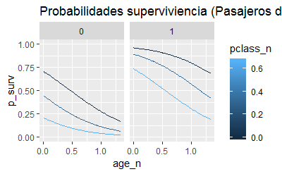

```r
# vamos a calcular proabilidades para estos datos
dat_calc <- expand.grid(list ( pclass_n = unique(x_ent[,"pclass_n"]),
                   age_n = unique(x_ent[, "age_n"]),
                   female = c(0,1),
                   southampton = 1,
                   cherbourg = 0))
mat_calc <- as.matrix(dat_calc)
## rellena aquí las betas que obtuviste
beta <- z2[2000,]
# calcula las probabilidades (puedes usar la fucnión p_beta, por ejemplo)
dat_calc$p_surv <- p_beta(mat_calc,beta)
ggplot(dat_calc, aes(x = age_n, y = p_surv, colour= pclass_n, group=pclass_n)) +
    facet_wrap(~female) + geom_line() + ylim(c(0, 1)) +
    labs(title = "Probabilidades superviviencia (Pasajeros de Southampton)")
```

¿Cuáles son las probabilidades más altas? ¿Cuáles son las más bajas? Mujeres jovenes de 1era clase son las que más probabilidad tienes de sobrevivir. Hombres mayores de 3era clase tienen menos probabildid de sobrevivir

5. ¿Cuál de los dos modelos anteriores (una sola variable, todas las variables) se desempeña mejor? ¿Por qué?

```r
devianza_pr <- devianza_calc(x_pr, y_pr)
devianza_pr(z2[2000,] )
```

[output not shown]

El segundo, ya que tiene menor devianza.

6. Calcula el error de clasificación de prueba

```r
prob_pr <- p_beta(x_pr,z2[2000,])
y_pred<-y_pr != as.numeric(prob_pr>0.5)
table(y_pred,y_pr)
```

```
       y_pr
y_pred    0   1
  FALSE 105  60
  TRUE   16  19
```

```r
mean(y_pred)
```

```
[1] 0.175
```

### Ejercicio C

Ahora supondremos que tenemos algunas variables adicionales para incluir en el modelo. En este ejercicio veremos qué sucede si estas variables **no** pueden ayudarnos a predecir (las simulamos al azar)

Dada la escala de nuestras variables, podemos simular variables con valores entre 0 y 1

```r
set.seed(1993)
p_ruido <- 50 # agregamos 50 variables sin información
n_ent <- nrow(x_ent)
n_pr <- nrow(x_pr)
mat_ent <- matrix(runif(n_ent * p_ruido), n_ent, p_ruido)
mat_pr <- matrix(runif(n_pr * p_ruido), n_pr, p_ruido)
#head(mat_ent)
```

1. Ajusta un modelo usando todas las variables, incluyendo las generadas aleatoriamente:

```r
devianza_ent3 <- devianza_calc(cbind(x_ent, mat_ent), y_ent)
grad_ent <- grad_calc(cbind(x_ent, mat_ent), y_ent)
## termina esta línea
z3 <- descenso(2000,c(rep(0,50+5+1)),0.0001,grad_ent)
#tail(z3,20)
```

2. Calcula ahora la devianza de prueba de este modelo

```r
devianza_pr <- devianza_calc(cbind(x_pr, mat_pr), y_pr)
devianza_pr(z3[2000,])
```

```
[1] 183.9601
```

Prueba utilizando otras semillas. Contesta:

- ¿Cómo es la devianza de prueba de el modelo con las variables ruidosas en comparación al modelo con las seis variables originales?
1. 169.623->201
2. 183.9601->1993
3. 172.7198->2018
4. 190.3876->54321

Más grande,

- ¿Podría ser que la devianza de prueba fuera un poco mejor para el modelo ruidoso?¿Por qué sí o por qué no?
- ¿Cómo se compara la devianza de *entrenamiento* del modelo con 6 variables con el modelo con todas las variables ruidosas?

```r
devianza_ent2(z2[2000,])
```

```
[1] 488.6212
```

```r
devianza_ent3(z3[2000,])
```

```
[1] 435.3632
```

Es más pequeaña la devianza de las variables ruidosas.

3. Haz pruebas agregando 2 o 3 variables ruidosas. ¿Qué tan grande es la diferencia entre la evaluación de los modelos?

```r
set.seed(1993)
p_ruido <- 3 # agregamos 50 variables sin información
n_ent <- nrow(x_ent)
n_pr <- nrow(x_pr)
mat_ent <- matrix(runif(n_ent * p_ruido), n_ent, p_ruido)
mat_pr <- matrix(runif(n_pr * p_ruido), n_pr, p_ruido)
#head(mat_ent)
devianza_ent4 <- devianza_calc(cbind(x_ent, mat_ent), y_ent)
grad_ent <- grad_calc(cbind(x_ent, mat_ent), y_ent)
## termina esta línea
z4 <- descenso(2000,c(rep(0,p_ruido+5+1)),0.0001,grad_ent)
tail(z4,20)
```

```
             [,1]      [,2]      [,3]     [,4]      [,5]      [,6]        [,7]       [,8]        [,9]
[1981,] 0.2017008 -2.530813 -1.043470 2.308416 0.2021881 0.7216265 -0.09722301 -0.3111707 -0.06301905
[1982,] 0.2018768 -2.531227 -1.043836 2.308448 0.2023838 0.7217736 -0.09721046 -0.3112256 -0.06301424
[1983,] 0.2020528 -2.531641 -1.044202 2.308479 0.2025793 0.7219206 -0.09719795 -0.3112805 -0.06300944
[1984,] 0.2022287 -2.532054 -1.044567 2.308511 0.2027747 0.7220675 -0.09718548 -0.3113354 -0.06300464
[1985,] 0.2024045 -2.532467 -1.044932 2.308542 0.2029700 0.7222143 -0.09717304 -0.3113902 -0.06299984
[1986,] 0.2025802 -2.532880 -1.045298 2.308573 0.2031652 0.7223611 -0.09716064 -0.3114450 -0.06299506
[1987,] 0.2027559 -2.533293 -1.045663 2.308605 0.2033603 0.7225078 -0.09714828 -0.3114999 -0.06299027
[1988,] 0.2029316 -2.533705 -1.046028 2.308636 0.2035553 0.7226545 -0.09713595 -0.3115547 -0.06298549
[1989,] 0.2031071 -2.534117 -1.046393 2.308667 0.2037501 0.7228011 -0.09712366 -0.3116094 -0.06298072
[1990,] 0.2032827 -2.534529 -1.046758 2.308698 0.2039449 0.7229476 -0.09711141 -0.3116642 -0.06297595
[1991,] 0.2034581 -2.534940 -1.047122 2.308730 0.2041395 0.7230940 -0.09709919 -0.3117189 -0.06297119
[1992,] 0.2036335 -2.535351 -1.047487 2.308761 0.2043340 0.7232404 -0.09708701 -0.3117737 -0.06296643
[1993,] 0.2038088 -2.535762 -1.047851 2.308792 0.2045284 0.7233868 -0.09707486 -0.3118284 -0.06296167
[1994,] 0.2039841 -2.536173 -1.048215 2.308823 0.2047226 0.7235330 -0.09706276 -0.3118831 -0.06295692
[1995,] 0.2041593 -2.536583 -1.048579 2.308854 0.2049168 0.7236792 -0.09705068 -0.3119377 -0.06295218
[1996,] 0.2043344 -2.536993 -1.048943 2.308885 0.2051108 0.7238253 -0.09703865 -0.3119924 -0.06294744
[1997,] 0.2045095 -2.537402 -1.049307 2.308916 0.2053048 0.7239714 -0.09702665 -0.3120470 -0.06294271
[1998,] 0.2046845 -2.537812 -1.049671 2.308947 0.2054986 0.7241174 -0.09701468 -0.3121017 -0.06293798
[1999,] 0.2048595 -2.538221 -1.050034 2.308978 0.2056923 0.7242634 -0.09700276 -0.3121563 -0.06293325
[2000,] 0.2050344 -2.538629 -1.050398 2.309009 0.2058859 0.7244092 -0.09699087 -0.3122108 -0.06292853
```

```r
devianza_ent4(z4[2000,])
```

```
[1] 490.9405
```

```r
devianza_pr <- devianza_calc(cbind(x_pr, mat_pr), y_pr)
devianza_pr(z4[2000,])
```

```
[1] 159.2574
```